# Effects of Diagram Standards on Students’ Monitoring Accuracy and Text Comprehension - Printed Summary of Analyses for Study 1 and 2

Sophia

2023-06-16

# Study 1 - Methods

## Participants, Design, Time On Task & Inter-Rater-Reliability of Measures

Descriptives of Age n = 80

| Mean | SD | Min | Max |
| --- | --- | --- | --- |
| 19.96 | 1.68 | 18 | 28 |

Gender Distribution n = 80

| Sex | n | % |
| --- | --- | --- |
| Female | 28 | 35 |
| Male | 52 | 65 |

Descriptives of Age n = 79

| Mean | SD | Min | Max |
| --- | --- | --- | --- |
| 19.96 | 1.69 | 18 | 28 |

Gender Distribution n = 79

| Sex | n | % |
| --- | --- | --- |
| Female | 28 | 35.44 |
| Male | 51 | 64.56 |

n (Previous Drop-Out & Final) and Time On Task per Condtition

| Experiment | Condition | n Drop_Out | n Final | Time On Task Mean | Time On Task SD | Time On Task Min | Time On Task Max |
| --- | --- | --- | --- | --- | --- | --- | --- |
| 1 | Diagramming-Only | 4 | 20 | 34.03 | 11.94 | 21.52 | 72.78 |
| 1 | Diagramming+Standard | 4 | 19 | 29.81 | 12.27 | 17.83 | 70.10 |
| 2 | Diagramming+Standard | 0+(2*) | 22(20) | 28.32 | 6.58 | 17.32 | 43.90 |
| 1 | No-Diagram-Control | 5 | 19 | 24.83 | 8.39 | 12.80 | 46.07 |
| 1 | Standard-Only | 2+1* | 21 | 17.84 | 6.32 | 9.20 | 33.77 |

Inter-Rater-Reliabilities of Diagram and Test Responses (squared kappa’s)

| **Diagram Responses** |  |
| --- | --- |
| Total Correct Scores | 0.94 |
| Correct Box Scores | 0.94 |
| Element Numbers | 0.93 |
| Commission Errors | 0.86 |
| **Test Responses** |  |
| Test Total Scores | 0.88 |

# Study 1 - Results

## *Descriptives Statistics*

Descriptive Per Factors - Pooled Conditions

| Factor | Abs. Monitoring Acc. Mean | Abs. Monitoring Acc. SD | Abs. Monitoring Acc. Min | Abs. Monitoring Acc. Max | Rel. Monitoring Acc. Mean | Rel. Monitoring Acc. SD | Rel. Monitoring Acc. Min | Rel. Monitoring Acc. Max | Text Comprehension Mean | Text Comprehension SD | Text Comprehension Min | Text Comprehension Max | JOL1 Mean | JOL1 SD | JOL1 Min | JOL1 Max | JOL2 Mean | JOL2 SD | JOL2 Min | JOL2 Max |
| --- | --- | --- | --- | --- | --- | --- | --- | --- | --- | --- | --- | --- | --- | --- | --- | --- | --- | --- | --- | --- |
| **Diagramming** |  |  |  |  |  |  |  |  |  |  |  |  |  |  |  |  |  |  |  |  |
| No | 0.88 | 0.80 | 0 | 4 | 0.29 | 0.65 | -1 | 1 | 3.07 | 0.97 | 0 | 4 | 2.45 | 0.89 | 0 | 4 | 2.68 | 0.94 | 0 | 4 |
| Yes | 0.84 | 0.73 | 0 | 3 | 0.30 | 0.61 | -1 | 1 | 3.35 | 0.79 | 1 | 4 | 2.40 | 0.89 | 0 | 4 | 2.87 | 0.98 | 0 | 4 |
| **Standard** |  |  |  |  |  |  |  |  |  |  |  |  |  |  |  |  |  |  |  |  |
| No | 1.00 | 0.86 | 0 | 4 | 0.22 | 0.58 | -1 | 1 | 2.99 | 0.95 | 0 | 4 | 2.54 | 0.86 | 0 | 4 | 2.49 | 1.01 | 0 | 4 |
| Yes | 0.72 | 0.64 | 0 | 3 | 0.39 | 0.67 | -1 | 1 | 3.43 | 0.78 | 0 | 4 | 2.31 | 0.90 | 0 | 4 | 3.05 | 0.83 | 0 | 4 |

Descriptive Per Condition

| Condition | Abs. Monitoring Acc. Mean | Abs. Monitoring Acc. SD | Abs. Monitoring Acc. Min | Abs. Monitoring Acc. Max | Rel. Monitoring Acc. Mean | Rel. Monitoring Acc. SD | Rel. Monitoring Acc. Min | Rel. Monitoring Acc. Max | Text Comprehension Mean | Text Comprehension SD | Text Comprehension Min | Text Comprehension Max | JOL1 Mean | JOL1 SD | JOL1 Min | JOL1 Max | JOL2 Mean | JOL2 SD | JOL2 Min | JOL2 Max |
| --- | --- | --- | --- | --- | --- | --- | --- | --- | --- | --- | --- | --- | --- | --- | --- | --- | --- | --- | --- | --- |
| **Study 1** |  |  |  |  |  |  |  |  |  |  |  |  |  |  |  |  |  |  |  |  |
| Diagramming+Standard | 0.68 | 0.61 | 0 | 3 | 0.38 | 0.68 | -1 | 1 | 3.65 | 0.56 | 1 | 4 | 2.27 | 0.91 | 0 | 4 | 3.18 | 0.79 | 0 | 4 |
| Diagramming-Only | 0.98 | 0.81 | 0 | 3 | 0.25 | 0.56 | -1 | 1 | 3.08 | 0.87 | 1 | 4 | 2.52 | 0.86 | 0 | 4 | 2.58 | 1.05 | 0 | 4 |
| Standard-Only | 0.75 | 0.67 | 0 | 3 | 0.40 | 0.68 | -1 | 1 | 3.23 | 0.89 | 0 | 4 | 2.34 | 0.90 | 0 | 4 | 2.94 | 0.86 | 0 | 4 |
| No-Diagram-Control | 1.02 | 0.91 | 0 | 4 | 0.19 | 0.61 | -1 | 1 | 2.90 | 1.02 | 0 | 4 | 2.57 | 0.87 | 1 | 4 | 2.40 | 0.96 | 0 | 4 |
| **Study 2** |  |  |  |  |  |  |  |  |  |  |  |  |  |  |  |  |  |  |  |  |
| Diagramming+Standard | 0.79 | 0.79 | 0 | 3 | 0.44 | 0.69 | -1 | 1 | 3.64 | 0.65 | 2 | 4 | 2.21 | 0.80 | 0 | 4 | 3.02 | 0.85 | 1 | 4 |

82.28% of participants’ judgements of learning differed ≤ 1 point from their actual test scores (i.e., absolute monitoring accuracy ≤ 1 in 82.28% of the cases).

## *Monitoring Accuracy*

### *With Pooled Factors as Predictors*

|  | absMonAcc |  |  |  |  |  |  | absMonAcc |  |  |  |  |  |  |
| --- | --- | --- | --- | --- | --- | --- | --- | --- | --- | --- | --- | --- | --- | --- |
| Predictors | Estimates | std. Error | std. Beta | standardized std. Error | CI | standardized CI | p | Estimates | std. Error | std. Beta | standardized std. Error | CI | standardized CI | p |
| (Intercept) | 1.02 | 0.08 | 0.21 | 0.11 | 0.85 – 1.18 | -0.01 – 0.43 | **<0.001** | 1.03 | 0.07 | 0.22 | 0.09 | 0.89 – 1.17 | 0.04 – 0.40 | **<0.001** |
| Diagramming [Yes] | -0.04 | 0.12 | -0.05 | 0.15 | -0.27 – 0.20 | -0.35 – 0.26 | 0.764 | -0.05 | 0.08 | -0.07 | 0.11 | -0.21 – 0.11 | -0.28 – 0.14 | 0.531 |
| Standard [Yes] | -0.27 | 0.12 | -0.35 | 0.15 | -0.50 – -0.04 | -0.65 – -0.05 | **0.023** | -0.28 | 0.08 | -0.37 | 0.11 | -0.44 – -0.12 | -0.58 – -0.16 | **0.001** |
| Diagramming [Yes] × Standard [Yes] | -0.03 | 0.17 | -0.04 | 0.22 | -0.36 – 0.29 | -0.47 – 0.38 | 0.846 |  |  |  |  |  |  |  |
| Random Effects |  |  |  |  |  |  |  |  |  |  |  |  |  |  |
| σ<sup>2</sup> | 0.53 |  |  |  |  |  |  | 0.53 |  |  |  |  |  |  |
| τ<sub>00</sub> | 0.05 <sub>ParticipantID</sub> |  |  |  |  |  |  | 0.04 <sub>ParticipantID</sub> |  |  |  |  |  |  |
| ICC | 0.08 |  |  |  |  |  |  | 0.08 |  |  |  |  |  |  |
| N | 79 <sub>ParticipantID</sub> |  |  |  |  |  |  | 79 <sub>ParticipantID</sub> |  |  |  |  |  |  |
| Observations | 471 |  |  |  |  |  |  | 471 |  |  |  |  |  |  |
| Marginal R<sup>2</sup> / Conditional R<sup>2</sup> | 0.034 / 0.113 |  |  |  |  |  |  | 0.034 / 0.110 |  |  |  |  |  |  |

The model with the interaction did not explain significantly more variance compared to the model fitting only main effects *Chi<sup>2</sup>*(1) = 0.04 *p* < 0.843.

### *With Conditions as Predictors*

|  | absMonAcc |  |  |  |  |  |  |
| --- | --- | --- | --- | --- | --- | --- | --- |
| Predictors | Estimates | std. Error | std. Beta | standardized std. Error | CI | standardized CI | p |
| (Intercept) | 1.02 | 0.08 | 0.21 | 0.11 | 0.85 – 1.18 | -0.01 – 0.43 | **<0.001** |
| Condition [Diagramming-Only] | -0.04 | 0.12 | -0.05 | 0.15 | -0.27 – 0.20 | -0.35 – 0.26 | 0.764 |
| Condition [Diagramming+Standard] | -0.33 | 0.12 | -0.44 | 0.16 | -0.57 – -0.10 | -0.74 – -0.13 | **0.005** |
| Condition [Standard-Only] | -0.27 | 0.12 | -0.35 | 0.15 | -0.50 – -0.04 | -0.65 – -0.05 | **0.023** |
| Random Effects |  |  |  |  |  |  |  |
| σ<sup>2</sup> | 0.53 |  |  |  |  |  |  |
| τ<sub>00</sub> <sub>ParticipantID</sub> | 0.05 |  |  |  |  |  |  |
| ICC | 0.08 |  |  |  |  |  |  |
| N <sub>ParticipantID</sub> | 79 |  |  |  |  |  |  |
| Observations | 471 |  |  |  |  |  |  |
| Marginal R<sup>2</sup> / Conditional R<sup>2</sup> | 0.034 / 0.113 |  |  |  |  |  |  |

### *Pairwise Comparisons*

| contrast | estimate | SE | df | t.ratio | p.value | effect.size |
| --- | --- | --- | --- | --- | --- | --- |
| No-Diagram-Control - Diagramming-Only | 0.04 | 0.12 | 74.79 | 0.30 | 0.990 | 0.05 |
| No-Diagram-Control - Diagramming+Standard | 0.33 | 0.12 | 74.78 | 2.80 | 0.032 | 0.46 |
| No-Diagram-Control - Standard-Only | 0.27 | 0.12 | 75.51 | 2.29 | 0.110 | 0.37 |
| Diagramming-Only - Diagramming+Standard | 0.30 | 0.12 | 74.37 | 2.54 | 0.061 | 0.41 |
| Diagramming-Only - Standard-Only | 0.23 | 0.11 | 75.10 | 2.01 | 0.192 | 0.32 |
| Diagramming+Standard - Standard-Only | -0.07 | 0.12 | 75.08 | -0.58 | 0.938 | -0.09 |

## *Relative Monitoring Accuracy*

|  | relMonitoringAccuracy |  |  |  |  |  |  | relMonitoringAccuracy |  |  |  |  |  |  |
| --- | --- | --- | --- | --- | --- | --- | --- | --- | --- | --- | --- | --- | --- | --- |
| Predictors | Estimates | std. Error | std. Beta | standardized std. Error | CI | standardized CI | p | Estimates | std. Error | std. Beta | standardized std. Error | CI | standardized CI | p |
| (Intercept) | 0.20 | 0.13 | -0.18 | 0.20 | -0.05 – 0.46 | -0.58 – 0.22 | 0.111 | 0.19 | 0.15 | -0.21 | 0.24 | -0.11 – 0.49 | -0.68 – 0.27 | 0.210 |
| Diagramming [Yes] | 0.03 | 0.14 | 0.05 | 0.23 | -0.25 – 0.31 | -0.40 – 0.50 | 0.834 | 0.06 | 0.21 | 0.09 | 0.33 | -0.35 – 0.47 | -0.56 – 0.74 | 0.780 |
| Standard [Yes] | 0.18 | 0.14 | 0.29 | 0.22 | -0.10 – 0.46 | -0.16 – 0.73 | 0.200 | 0.21 | 0.22 | 0.34 | 0.35 | -0.22 – 0.65 | -0.35 – 1.03 | 0.334 |
| Diagramming [Yes] × Standard [Yes] |  |  |  |  |  |  |  | -0.05 | 0.29 | -0.08 | 0.45 | -0.62 – 0.52 | -0.99 – 0.82 | 0.852 |
| Observations | 83 |  |  |  |  |  |  | 83 |  |  |  |  |  |  |
| R<sup>2</sup> / R<sup>2</sup> adjusted | 0.022 / -0.002 |  |  |  |  |  |  | 0.023 / -0.015 |  |  |  |  |  |  |

## *Text Comprehension*

### *With Pooled Factors as Predictors*

|  | Test |  |  |  |  |  |  | Test |  |  |  |  |  |  |
| --- | --- | --- | --- | --- | --- | --- | --- | --- | --- | --- | --- | --- | --- | --- |
| Predictors | Estimates | std. Error | std. Beta | standardized std. Error | CI | standardized CI | p | Estimates | std. Error | std. Beta | standardized std. Error | CI | standardized CI | p |
| (Intercept) | 2.83 | 0.09 | -0.42 | 0.10 | 2.65 – 3.01 | -0.63 – -0.22 | **<0.001** | 2.90 | 0.11 | -0.35 | 0.12 | 2.69 – 3.11 | -0.59 – -0.12 | **<0.001** |
| Diagramming [Yes] | 0.30 | 0.11 | 0.34 | 0.12 | 0.10 – 0.51 | 0.11 – 0.57 | **0.004** | 0.18 | 0.15 | 0.20 | 0.17 | -0.12 – 0.47 | -0.13 – 0.53 | 0.237 |
| Standard [Yes] | 0.45 | 0.11 | 0.50 | 0.12 | 0.24 – 0.66 | 0.27 – 0.73 | **<0.001** | 0.32 | 0.15 | 0.36 | 0.17 | 0.03 – 0.61 | 0.04 – 0.69 | **0.029** |
| Diagramming [Yes] × Standard [Yes] |  |  |  |  |  |  |  | 0.25 | 0.21 | 0.28 | 0.24 | -0.16 – 0.66 | -0.18 – 0.74 | 0.234 |
| Random Effects |  |  |  |  |  |  |  |  |  |  |  |  |  |  |
| σ<sup>2</sup> | 0.62 |  |  |  |  |  |  | 0.62 |  |  |  |  |  |  |
| τ<sub>00</sub> | 0.12 <sub>ParticipantID</sub> |  |  |  |  |  |  | 0.11 <sub>ParticipantID</sub> |  |  |  |  |  |  |
| ICC | 0.16 |  |  |  |  |  |  | 0.16 |  |  |  |  |  |  |
| N | 79 <sub>ParticipantID</sub> |  |  |  |  |  |  | 79 <sub>ParticipantID</sub> |  |  |  |  |  |  |
| Observations | 471 |  |  |  |  |  |  | 471 |  |  |  |  |  |  |
| Marginal R<sup>2</sup> / Conditional R<sup>2</sup> | 0.088 / 0.231 |  |  |  |  |  |  | 0.093 / 0.234 |  |  |  |  |  |  |

The model with the interaction did not explain significantly more variance compared to the model fitting only main effects *Chi<sup>2</sup>*(1) = 1.48 *p* = 0.224.

### *With Conditions as Predictors*

|  | Test |  |  |  |  |  |  |
| --- | --- | --- | --- | --- | --- | --- | --- |
| Predictors | Estimates | std. Error | std. Beta | standardized std. Error | CI | standardized CI | p |
| (Intercept) | 2.90 | 0.11 | -0.35 | 0.12 | 2.69 – 3.11 | -0.59 – -0.12 | **<0.001** |
| Condition [Diagramming-Only] | 0.18 | 0.15 | 0.20 | 0.17 | -0.12 – 0.47 | -0.13 – 0.53 | 0.237 |
| Condition [Diagramming+Standard] | 0.75 | 0.15 | 0.84 | 0.17 | 0.45 – 1.05 | 0.51 – 1.17 | **<0.001** |
| Condition [Standard-Only] | 0.32 | 0.15 | 0.36 | 0.17 | 0.03 – 0.61 | 0.04 – 0.69 | **0.029** |
| Random Effects |  |  |  |  |  |  |  |
| σ<sup>2</sup> | 0.62 |  |  |  |  |  |  |
| τ<sub>00</sub> <sub>ParticipantID</sub> | 0.11 |  |  |  |  |  |  |
| ICC | 0.16 |  |  |  |  |  |  |
| N <sub>ParticipantID</sub> | 79 |  |  |  |  |  |  |
| Observations | 471 |  |  |  |  |  |  |
| Marginal R<sup>2</sup> / Conditional R<sup>2</sup> | 0.093 / 0.234 |  |  |  |  |  |  |

### *Pairwise comparisons*

| contrast | estimate | SE | df | t.ratio | p.value | effect.size |
| --- | --- | --- | --- | --- | --- | --- |
| No-Diagram-Control - Diagramming-Only | -0.18 | 0.15 | 74.85 | -1.18 | 0.639 | -0.22 |
| No-Diagram-Control - Diagramming+Standard | -0.75 | 0.15 | 74.84 | -4.96 | 0.000 | -0.95 |
| No-Diagram-Control - Standard-Only | -0.32 | 0.15 | 75.40 | -2.19 | 0.136 | -0.41 |
| Diagramming-Only - Diagramming+Standard | -0.57 | 0.15 | 74.52 | -3.85 | 0.001 | -0.73 |
| Diagramming-Only - Standard-Only | -0.15 | 0.15 | 75.08 | -1.01 | 0.746 | -0.19 |
| Diagramming+Standard - Standard-Only | 0.43 | 0.15 | 75.07 | 2.89 | 0.025 | 0.54 |

## *Judgements of Learning*

|  | JoL_Response |  |  |  |  |  |  |
| --- | --- | --- | --- | --- | --- | --- | --- |
| Predictors | Estimates | std. Error | std. Beta | standardized std. Error | CI | standardized CI | p |
| (Intercept) | 2.57 | 0.14 | -0.03 | 0.15 | 2.30 – 2.84 | -0.32 – 0.26 | **<0.001** |
| JoL Instance [JoL2] | -0.17 | 0.10 | -0.18 | 0.10 | -0.36 – 0.03 | -0.38 – 0.03 | 0.089 |
| Condition [Diagramming-Only] | -0.05 | 0.19 | -0.06 | 0.21 | -0.43 – 0.33 | -0.46 – 0.35 | 0.783 |
| Condition [Diagramming+Standard] | -0.30 | 0.20 | -0.32 | 0.21 | -0.68 – 0.09 | -0.73 – 0.09 | 0.130 |
| Condition [Standard-Only] | -0.23 | 0.19 | -0.24 | 0.20 | -0.61 – 0.15 | -0.64 – 0.16 | 0.233 |
| JoL Instance [JoL2] × Condition [Diagramming-Only] | 0.22 | 0.14 | 0.24 | 0.15 | -0.04 – 0.49 | -0.05 – 0.52 | 0.101 |
| JoL Instance [JoL2] × Condition [Diagramming+Standard] | 1.07 | 0.14 | 1.14 | 0.15 | 0.80 – 1.34 | 0.85 – 1.42 | **<0.001** |
| JoL Instance [JoL2] × Condition [Standard-Only] | 0.76 | 0.14 | 0.81 | 0.14 | 0.50 – 1.03 | 0.53 – 1.09 | **<0.001** |
| Random Effects |  |  |  |  |  |  |  |
| σ<sup>2</sup> | 0.55 |  |  |  |  |  |  |
| τ<sub>00</sub> <sub>ParticipantID</sub> | 0.28 |  |  |  |  |  |  |
| ICC | 0.34 |  |  |  |  |  |  |
| N <sub>ParticipantID</sub> | 79 |  |  |  |  |  |  |
| Observations | 948 |  |  |  |  |  |  |
| Marginal R<sup>2</sup> / Conditional R<sup>2</sup> | 0.091 / 0.396 |  |  |  |  |  |  |

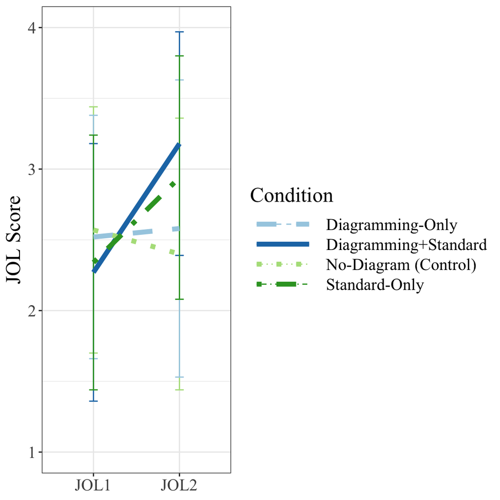

The model with the interaction explained significantly more variance compared to the model fitting only main effects *Chi<sup>2</sup>*(3) = 73.08 *p* = 0.000.

### *Pairwise Comparisons*

| contrast | estimate | SE | df | t.ratio | p.value | effect.size |
| --- | --- | --- | --- | --- | --- | --- |
| JoL1 No-Diagram-Control - JoL2 No-Diagram-Control | 0.17 | 0.10 | 865.00 | 1.70 | 0.687 | 0.23 |
| JoL1 No-Diagram-Control - JoL1 Diagramming-Only | 0.05 | 0.19 | 97.61 | 0.28 | 1.000 | 0.07 |
| JoL1 No-Diagram-Control - JoL2 Diagramming-Only | 0.00 | 0.19 | 97.61 | -0.02 | 1.000 | -0.01 |
| JoL1 No-Diagram-Control - JoL1 Diagramming+Standard | 0.30 | 0.20 | 97.61 | 1.52 | 0.797 | 0.40 |
| JoL1 No-Diagram-Control - JoL2 Diagramming+Standard | -0.61 | 0.20 | 97.61 | -3.08 | 0.053 | -0.82 |
| JoL1 No-Diagram-Control - JoL1 Standard-Only | 0.23 | 0.19 | 97.61 | 1.19 | 0.932 | 0.31 |
| JoL1 No-Diagram-Control - JoL2 Standard-Only | -0.37 | 0.19 | 97.61 | -1.91 | 0.549 | -0.49 |
| JoL2 No-Diagram-Control - JoL1 Diagramming-Only | -0.11 | 0.19 | 97.61 | -0.58 | 0.999 | -0.15 |
| JoL2 No-Diagram-Control - JoL2 Diagramming-Only | -0.17 | 0.19 | 97.61 | -0.88 | 0.987 | -0.23 |
| JoL2 No-Diagram-Control - JoL1 Diagramming+Standard | 0.13 | 0.20 | 97.61 | 0.67 | 0.998 | 0.18 |
| JoL2 No-Diagram-Control - JoL2 Diagramming+Standard | -0.77 | 0.20 | 97.61 | -3.92 | 0.004 | -1.04 |
| JoL2 No-Diagram-Control - JoL1 Standard-Only | 0.06 | 0.19 | 97.61 | 0.32 | 1.000 | 0.08 |
| JoL2 No-Diagram-Control - JoL2 Standard-Only | -0.53 | 0.19 | 97.61 | -2.78 | 0.113 | -0.72 |
| JoL1 Diagramming-Only - JoL2 Diagramming-Only | -0.06 | 0.10 | 865.00 | -0.61 | 0.999 | -0.08 |
| JoL1 Diagramming-Only - JoL1 Diagramming+Standard | 0.24 | 0.19 | 97.61 | 1.26 | 0.911 | 0.33 |
| JoL1 Diagramming-Only - JoL2 Diagramming+Standard | -0.66 | 0.19 | 97.61 | -3.39 | 0.022 | -0.89 |
| JoL1 Diagramming-Only - JoL1 Standard-Only | 0.18 | 0.19 | 97.61 | 0.93 | 0.983 | 0.24 |
| JoL1 Diagramming-Only - JoL2 Standard-Only | -0.42 | 0.19 | 97.61 | -2.22 | 0.351 | -0.57 |
| JoL2 Diagramming-Only - JoL1 Diagramming+Standard | 0.30 | 0.19 | 97.61 | 1.56 | 0.772 | 0.41 |
| JoL2 Diagramming-Only - JoL2 Diagramming+Standard | -0.60 | 0.19 | 97.61 | -3.09 | 0.051 | -0.81 |
| JoL2 Diagramming-Only - JoL1 Standard-Only | 0.23 | 0.19 | 97.61 | 1.23 | 0.920 | 0.32 |
| JoL2 Diagramming-Only - JoL2 Standard-Only | -0.36 | 0.19 | 97.61 | -1.91 | 0.549 | -0.49 |
| JoL1 Diagramming+Standard - JoL2 Diagramming+Standard | -0.90 | 0.10 | 865.00 | -9.22 | 0.000 | -1.22 |
| JoL1 Diagramming+Standard - JoL1 Standard-Only | -0.07 | 0.19 | 97.61 | -0.36 | 1.000 | -0.09 |
| JoL1 Diagramming+Standard - JoL2 Standard-Only | -0.66 | 0.19 | 97.61 | -3.46 | 0.017 | -0.90 |
| JoL2 Diagramming+Standard - JoL1 Standard-Only | 0.83 | 0.19 | 97.61 | 4.35 | 0.001 | 1.13 |
| JoL2 Diagramming+Standard - JoL2 Standard-Only | 0.24 | 0.19 | 97.61 | 1.24 | 0.916 | 0.32 |
| JoL1 Standard-Only - JoL2 Standard-Only | -0.60 | 0.09 | 865.00 | -6.38 | 0.000 | -0.80 |

# Study 2 - Methods

## Participants, Data Exclusion, Inter-Rate-Reliabilities & Reported Gaze Deviation

Descriptives of Age

| Mean | SD | Min | Max |
| --- | --- | --- | --- |
| 20.12 | 1.41 | 18 | 22 |

Gender Distribution

| Gender | n | % |
| --- | --- | --- |
| female | 17 | 77.27 |
| male | 5 | 22.73 |

Exclusion Criteria and Cases

|  | Cut-Off | n |
| --- | --- | --- |
| **Exclusion of** |  |  |
| Calibration Values | 1.34 | 2 |
| Tracking Ratios | < 75% | 0 |
| **Gaze Data of Participants Analysed** |  |  |
|  |  | 20 |

Agreement of raters for segmentation of verbal reports for coding

| (Dis-)Agreement | Perspective Coder 1 n | Perspective Coder 1 total segments | Perspective Coder 1 1 - n/total segments | Perspective Coder 1 n | Perspective Coder 1 total segments | Perspective Coder 1 1 - n/total segments |
| --- | --- | --- | --- | --- | --- | --- |
| Disagreement | 41 | 362 | **88.67** | 65 | 386 | **83.16** |
| Agreement | 321 | 362 | 11.33 | 321 | 386 | 16.84 |

Accuracy reported by the eye-tracker software was *M* = 0.55 (0.18).

# Study 2 - Results

## *Descriptives Fixations*

Descriptive Statistics of Total Fixation Durations per Diagram and Cue Type

| DiagramType | CueType | No. of diagram boxes in eye-tracking data/ No. of diagram boxes in performance data n Gaze Data | No. of diagram boxes in eye-tracking data/ No. of diagram boxes in performance data n Performance Data | Average Total Fixation Duration of Single Box Per Cue Type (seconds) Mean | Average Total Fixation Duration of Single Box Per Cue Type (seconds) SD | % Total Fixations on Screen relative to screen duration Mean | % Total Fixations on Screen relative to screen duration SD |
| --- | --- | --- | --- | --- | --- | --- | --- |
| Own Diagram |  |  |  |  |  | 21.59 | (10.82) |
|  | Commission | 73 | 80 | 1.21 | (0.79) | 2.99 | (4.49) |
|  | Correct | 322 | 352 | 1.29 | (1.11) | 16.85 | (11.5) |
|  | GivenBox | 65 | 117 | 0.57 | (0.64) | 1.31 | (2.05) |
|  | Omission | 21 | 31 | 0.4 | (0.33) | 0.45 | (1.61) |
| Standard |  |  |  |  |  | 61.42 | (14.58) |
|  | Commission | 79 | 80 | 4.53 | (3.93) | 11.44 | (17.31) |
|  | Correct | 351 | 352 | 2.93 | (2.32) | 40.47 | (17.24) |
|  | GivenBox | 115 | 117 | 1.42 | (1.63) | 5.75 | (4.61) |
|  | Omission | 31 | 31 | 3.09 | (2.78) | 3.76 | (8.44) |
| Outside Diagrams/AOIs |  |  |  | 4.51 | (6.3) | 16.99 | (10.7) |

Word Count of Diagram Responses

| DiagramType | Mean | SD | Min | Max |
| --- | --- | --- | --- | --- |
| Own Diagram | 7.86 | 3.93 | 0 | 21 |
| Standard | 6.13 | 2.35 | 3 | 12 |

Participants wrote on average 1.73 words more in a box of their own diagram compared to words in a box of the standard.

## *Analysis Fixation Durations*

|  | sumAoiFixationDuration_Sec |  |  |  |  |  |  |
| --- | --- | --- | --- | --- | --- | --- | --- |
| Predictors | Estimates | std. Error | std. Beta | standardized std. Error | CI | standardized CI | p |
| (Intercept) | 1.13 | 0.26 | -0.42 | 0.12 | 0.61 – 1.65 | -0.65 – -0.19 | **<0.001** |
| DiagramType [StandardDiagram] | 3.39 | 0.31 | 1.51 | 0.14 | 2.79 – 3.99 | 1.24 – 1.77 | **<0.001** |
| CueType [Correct] | 0.13 | 0.25 | 0.06 | 0.11 | -0.36 – 0.62 | -0.16 – 0.27 | 0.603 |
| CueType [GivenBox] | -0.71 | 0.32 | -0.32 | 0.14 | -1.34 – -0.08 | -0.60 – -0.03 | **0.028** |
| CueType [Omission] | -0.65 | 0.47 | -0.29 | 0.21 | -1.58 – 0.27 | -0.70 – 0.12 | 0.165 |
| DiagramType [StandardDiagram] × CueType [Correct] | -1.71 | 0.34 | -0.76 | 0.15 | -2.37 – -1.05 | -1.05 – -0.46 | **<0.001** |
| DiagramType [StandardDiagram] × CueType [GivenBox] | -2.39 | 0.42 | -1.06 | 0.19 | -3.22 – -1.56 | -1.43 – -0.69 | **<0.001** |
| DiagramType [StandardDiagram] × CueType [Omission] | -0.75 | 0.61 | -0.34 | 0.27 | -1.96 – 0.45 | -0.87 – 0.20 | 0.220 |
| Random Effects |  |  |  |  |  |  |  |
| σ<sup>2</sup> | 3.54 |  |  |  |  |  |  |
| τ<sub>00</sub> <sub>Participant</sub> | 0.39 |  |  |  |  |  |  |
| ICC | 0.10 |  |  |  |  |  |  |
| N <sub>Participant</sub> | 20 |  |  |  |  |  |  |
| Observations | 1057 |  |  |  |  |  |  |
| Marginal R<sup>2</sup> / Conditional R<sup>2</sup> | 0.243 / 0.318 |  |  |  |  |  |  |

### *Pairwise comparisons*

| contrast | estimate | SE | df | t.ratio | p.value | effect.size |
| --- | --- | --- | --- | --- | --- | --- |
| OwnDiagram Commission - StandardDiagram Commission | -3.39 | 0.31 | 1030.49 | -11.10 | 0.000 | -1.80 |
| OwnDiagram Commission - OwnDiagram Correct | -0.13 | 0.25 | 1041.99 | -0.52 | 1.000 | -0.07 |
| OwnDiagram Commission - StandardDiagram Correct | -1.81 | 0.25 | 1041.98 | -7.33 | 0.000 | -0.96 |
| OwnDiagram Commission - OwnDiagram GivenBox | 0.71 | 0.32 | 1035.38 | 2.20 | 0.354 | 0.38 |
| OwnDiagram Commission - StandardDiagram GivenBox | -0.29 | 0.28 | 1037.14 | -1.01 | 0.973 | -0.15 |
| OwnDiagram Commission - OwnDiagram Omission | 0.65 | 0.47 | 1037.18 | 1.39 | 0.863 | 0.35 |
| OwnDiagram Commission - StandardDiagram Omission | -1.98 | 0.41 | 1041.47 | -4.82 | 0.000 | -1.05 |
| StandardDiagram Commission - OwnDiagram Correct | 3.26 | 0.24 | 1042.46 | 13.52 | 0.000 | 1.73 |
| StandardDiagram Commission - StandardDiagram Correct | 1.58 | 0.24 | 1042.02 | 6.61 | 0.000 | 0.84 |
| StandardDiagram Commission - OwnDiagram GivenBox | 4.10 | 0.32 | 1035.60 | 12.92 | 0.000 | 2.18 |
| StandardDiagram Commission - StandardDiagram GivenBox | 3.11 | 0.28 | 1037.06 | 11.17 | 0.000 | 1.65 |
| StandardDiagram Commission - OwnDiagram Omission | 4.05 | 0.47 | 1037.03 | 8.67 | 0.000 | 2.15 |
| StandardDiagram Commission - StandardDiagram Omission | 1.41 | 0.41 | 1041.52 | 3.47 | 0.013 | 0.75 |
| OwnDiagram Correct - StandardDiagram Correct | -1.68 | 0.15 | 1030.83 | -11.57 | 0.000 | -0.89 |
| OwnDiagram Correct - OwnDiagram GivenBox | 0.84 | 0.26 | 1033.25 | 3.27 | 0.025 | 0.45 |
| OwnDiagram Correct - StandardDiagram GivenBox | -0.16 | 0.20 | 1031.23 | -0.77 | 0.994 | -0.08 |
| OwnDiagram Correct - OwnDiagram Omission | 0.78 | 0.43 | 1036.13 | 1.83 | 0.599 | 0.42 |
| OwnDiagram Correct - StandardDiagram Omission | -1.85 | 0.36 | 1039.91 | -5.16 | 0.000 | -0.99 |
| StandardDiagram Correct - OwnDiagram GivenBox | 2.52 | 0.26 | 1033.44 | 9.88 | 0.000 | 1.34 |
| StandardDiagram Correct - StandardDiagram GivenBox | 1.52 | 0.20 | 1030.77 | 7.53 | 0.000 | 0.81 |
| StandardDiagram Correct - OwnDiagram Omission | 2.47 | 0.43 | 1035.81 | 5.78 | 0.000 | 1.31 |
| StandardDiagram Correct - StandardDiagram Omission | -0.17 | 0.36 | 1039.71 | -0.48 | 1.000 | -0.09 |
| OwnDiagram GivenBox - StandardDiagram GivenBox | -1.00 | 0.29 | 1032.05 | -3.41 | 0.016 | -0.53 |
| OwnDiagram GivenBox - OwnDiagram Omission | -0.06 | 0.48 | 1035.15 | -0.12 | 1.000 | -0.03 |
| OwnDiagram GivenBox - StandardDiagram Omission | -2.69 | 0.42 | 1037.99 | -6.48 | 0.000 | -1.43 |
| StandardDiagram GivenBox - OwnDiagram Omission | 0.94 | 0.45 | 1034.71 | 2.09 | 0.420 | 0.50 |
| StandardDiagram GivenBox - StandardDiagram Omission | -1.70 | 0.39 | 1037.77 | -4.40 | 0.000 | -0.90 |
| OwnDiagram Omission - StandardDiagram Omission | -2.64 | 0.53 | 1032.11 | -4.95 | 0.000 | -1.40 |

## *Transition Table*

Average Number of Transitions per Trial and Transition Type

Transition Type

Code

n

% of Total

% Within Category

**Total Transitions**

Total number of all transitions

2426

100.00

NA

**Between Diagrams**

Transitions between own diagram and standard

963

39.69

39.69

Correct box in own diagram - standard

1.a

720

29.68

74.77

Correct box in own diagram - matching box position in standard

a

115

4.74

15.97

Correct box in own diagram - matching content in standard

a

66

2.72

9.17

Correct box in own diagram - matching position and content in standard

a

319

13.15

44.31

Correct box in own diagram - not matching box content or position in standard

a

220

9.07

30.56

Mistake in own diagram - standard

1.ii

186

7.67

19.31

Commission - Standard

1.b

169

6.97

90.86

Commission in own diagram - matching box position in standard

b

84

3.46

49.70

Commission in own diagram - matching content* in standard

b

5

0.21

2.96

Commission in own diagram - matching position and content in standard

b

28

1.15

16.57

Commission in own diagram - not matching box content or position in standard

b

52

2.14

30.77

Omission - Standard

1.c

17

0.70

9.14

Omission in own diagram - matching box position in standard

c

7

0.29

41.18

Omission in own diagram - not matching box position in standard

c

10

0.41

58.82

Given box in own diagram - standard

1.d

57

2.35

5.92

**Within Diagrams**

Transitions within diagrams

1463

60.31

60.31

Within own diagram

2.a

317

13.07

21.67

Within standard

2.b

1146

47.24

78.33

Participants made between 55 and 204 fixation transitions throughout the study, ( *M* = 121.3, *SD* = 38).

## *Cued Retrospective Verbal Reports*

Average Frequencies and Proportion of Code Categories per Participant and Entire Sample

| Code | During Diagram Study & JOL Screen Total n | During Diagram Study & JOL Screen Total % | During Diagram Study & JOL Screen Average frequency per participant Mean | During Diagram Study & JOL Screen Average frequency per participant SD | During Diagram Study & JOL Screen Mentioned by n | During Diagram Study & JOL Screen Mentioned by % | During JOL Screen Only Total n | During JOL Screen Only Total % | During JOL Screen Only Average frequency per participant Mean | During JOL Screen Only Average frequency per participant SD | During JOL Screen Only Mentioned by n | During JOL Screen Only Mentioned by % |
| --- | --- | --- | --- | --- | --- | --- | --- | --- | --- | --- | --- | --- |
| 1 | 50 | 3.69 | 2.94 | 2.86 | 17 | 80.95 | 8 | 1.90 | 1.33 | 0.52 | 6 | 28.57 |
| 2 | 2 | 0.15 | 1.00 | 0.00 | 2 | 9.52 | 1 | 0.24 | 1.00 | NA | 1 | 4.76 |
| 3 | 44 | 3.25 | 2.75 | 1.65 | 16 | 76.19 | 7 | 1.66 | 1.17 | 0.41 | 6 | 28.57 |
| 4 | 8 | 0.59 | 1.60 | 0.89 | 5 | 23.81 | 3 | 0.71 | 1.50 | 0.71 | 2 | 9.52 |
| 5 | 34 | 2.51 | 2.00 | 1.06 | 17 | 80.95 | 5 | 1.18 | 1.00 | 0.00 | 5 | 23.81 |
| 6 | 5 | 0.37 | 1.25 | 0.50 | 4 | 19.05 | NA | NA | NA | NA | NA | NA |
| 7a | 45 | 3.32 | 2.65 | 1.41 | 17 | 80.95 | 10 | 2.37 | 1.43 | 0.53 | 7 | 33.33 |
| 7b | 36 | 2.66 | 1.89 | 1.05 | 19 | 90.48 | 15 | 3.55 | 1.50 | 0.71 | 10 | 47.62 |
| 8a | 65 | 4.80 | 3.42 | 2.59 | 19 | 90.48 | 2 | 0.47 | 1.00 | 0.00 | 2 | 9.52 |
| 8b | 26 | 1.92 | 1.86 | 1.29 | 14 | 66.67 | 1 | 0.24 | 1.00 | NA | 1 | 4.76 |
| 8c | 109 | 8.05 | 5.45 | 3.43 | 20 | 95.24 | 9 | 2.13 | 1.29 | 0.49 | 7 | 33.33 |
| 8d | 90 | 6.65 | 5.00 | 4.84 | 18 | 85.71 | 1 | 0.24 | 1.00 | NA | 1 | 4.76 |
| 9 | 105 | 7.75 | 5.53 | 4.22 | 19 | 90.48 | 10 | 2.37 | 2.00 | 1.00 | 5 | 23.81 |
| 10a | 118 | 8.71 | 5.62 | 4.73 | 21 | 100.00 | 33 | 7.82 | 3.00 | 2.79 | 11 | 52.38 |
| 10b | 54 | 3.99 | 3.60 | 3.54 | 15 | 71.43 | 10 | 2.37 | 1.67 | 0.82 | 6 | 28.57 |
| 11 | 19 | 1.40 | 2.11 | 1.54 | 9 | 42.86 | 16 | 3.79 | 2.00 | 1.69 | 8 | 38.10 |
| 12 | 32 | 2.36 | 3.20 | 1.81 | 10 | 47.62 | 17 | 4.03 | 2.12 | 1.25 | 8 | 38.10 |
| 13a | 249 | 18.39 | 11.86 | 4.63 | 21 | 100.00 | 155 | 36.73 | 7.38 | 2.97 | 21 | 100.00 |
| 13b | 76 | 5.61 | 4.00 | 1.73 | 19 | 90.48 | 73 | 17.30 | 3.84 | 1.89 | 19 | 90.48 |
| 14 | 4 | 0.30 | 2.00 | 1.41 | 2 | 9.52 | NA | NA | NA | NA | NA | NA |
| 15 | 183 | 13.52 | 9.15 | 6.34 | 20 | 95.24 | 46 | 10.90 | 2.71 | 1.57 | 17 | 80.95 |

The total number of coded segments was 1354, with 422 voiced during the JOL screen.

## *Cue Values, Cue Diagnosticity and Cue Utilization*

### *Study 1 and 2*

Descriptive Statistics Cue Values, Cue Diagnosticity and Cue Utilization

| Experiment | Condition | Correct Mean | Correct SD | Correct Min | Correct Max | Correct NAs | Commission Mean | Commission SD | Commission Min | Commission Max | Commission NAs | Omission Mean | Omission SD | Omission Min | Omission Max | Omission NAs |
| --- | --- | --- | --- | --- | --- | --- | --- | --- | --- | --- | --- | --- | --- | --- | --- | --- |
| **Cue Value** |  |  |  |  |  |  |  |  |  |  |  |  |  |  |  |  |
| 1 | Diagramming+Standard | 2.97 | 0.97 | 0.00 | 4.00 | 0 | 0.73 | 0.77 | 0.00 | 3.00 | 0 | 0.36 | 0.65 | 0.00 | 3.00 | 0 |
| 1 | Diagramming-Only | 3.12 | 0.88 | 1.00 | 4.00 | 0 | 0.64 | 0.73 | 0.00 | 3.00 | 0 | 0.28 | 0.60 | 0.00 | 3.00 | 0 |
| 2 | Diagramming+Standard | 3.02 | 0.95 | 1.00 | 4.00 | 0 | 0.82 | 0.91 | 0.00 | 3.00 | 0 | 0.26 | 0.55 | 0.00 | 3.00 | 0 |
| **Cue Diagnosticity** |  |  |  |  |  |  |  |  |  |  |  |  |  |  |  |  |
| 1 | Diagramming+Standard | 0.28 | 0.41 | -0.37 | 0.87 | 3 | -0.21 | 0.57 | -1.00 | 0.61 | 5 | -0.19 | 0.43 | -0.77 | 0.46 | 4 |
| 1 | Diagramming-Only | 0.60 | 0.29 | -0.11 | 1.00 | 0 | -0.34 | 0.41 | -0.91 | 0.71 | 0 | -0.51 | 0.35 | -1.00 | 0.17 | 4 |
| 2 | Diagramming+Standard | 0.29 | 0.49 | -0.46 | 0.88 | 7 | -0.22 | 0.57 | -0.85 | 0.54 | 7 | -0.11 | 0.44 | -0.76 | 0.45 | 12 |
| **Cue Utilization** |  |  |  |  |  |  |  |  |  |  |  |  |  |  |  |  |
| 1 | Diagramming+Standard | 0.44 | 0.32 | -0.11 | 0.97 | 1 | -0.17 | 0.38 | -0.86 | 0.45 | 2 | -0.33 | 0.36 | -0.89 | 0.45 | 3 |
| 1 | Diagramming-Only | 0.45 | 0.37 | -0.72 | 0.77 | 0 | -0.14 | 0.39 | -0.85 | 0.43 | 0 | -0.52 | 0.46 | -1.00 | 0.79 | 4 |
| 2 | Diagramming+Standard | 0.56 | 0.27 | -0.03 | 0.88 | 2 | -0.38 | 0.38 | -0.88 | 0.49 | 1 | -0.48 | 0.33 | -0.91 | 0.00 | 7 |

### *Differences between conditions of Study 1*

|  | CueValue_Correct |  |  | CueValue_Commission |  |  | CueValue_Omission |  |  |
| --- | --- | --- | --- | --- | --- | --- | --- | --- | --- |
| Predictors | Estimates | CI | p | Estimates | CI | p | Estimates | CI | p |
| (Intercept) | 3.12 | 2.96 – 3.29 | **<0.001** | 0.64 | 0.51 – 0.78 | **<0.001** | 0.28 | 0.17 – 0.40 | **<0.001** |
| Condition [Diagramming+Standard] | -0.15 | -0.39 – 0.09 | 0.212 | 0.09 | -0.11 – 0.28 | 0.379 | 0.08 | -0.08 – 0.24 | 0.351 |
| Observations | 234 |  |  | 234 |  |  | 234 |  |  |
| R<sup>2</sup> / R<sup>2</sup> adjusted | 0.007 / 0.002 |  |  | 0.003 / -0.001 |  |  | 0.004 / -0.001 |  |  |

|  | CueDiag_Correct |  |  | CueDiag_Commission |  |  | CueDiag_Omission |  |  |
| --- | --- | --- | --- | --- | --- | --- | --- | --- | --- |
| Predictors | Estimates | CI | p | Estimates | CI | p | Estimates | CI | p |
| (Intercept) | 0.60 | 0.44 – 0.76 | **<0.001** | -0.34 | -0.56 – -0.12 | **0.003** | -0.51 | -0.71 – -0.31 | **<0.001** |
| Condition [Diagramming+Standard] | -0.32 | -0.56 – -0.08 | **0.009** | 0.13 | -0.21 – 0.47 | 0.449 | 0.32 | 0.03 – 0.61 | **0.032** |
| Observations | 36 |  |  | 34 |  |  | 31 |  |  |
| R<sup>2</sup> / R<sup>2</sup> adjusted | 0.183 / 0.159 |  |  | 0.018 / -0.013 |  |  | 0.150 / 0.120 |  |  |

|  | CueUtil_Correct |  |  | CueUtil_Commission |  |  | CueUtil_Omission |  |  |
| --- | --- | --- | --- | --- | --- | --- | --- | --- | --- |
| Predictors | Estimates | CI | p | Estimates | CI | p | Estimates | CI | p |
| (Intercept) | 0.45 | 0.29 – 0.60 | **<0.001** | -0.14 | -0.31 – 0.03 | 0.110 | -0.52 | -0.74 – -0.31 | **<0.001** |
| Condition [Diagramming+Standard] | -0.01 | -0.24 – 0.22 | 0.930 | -0.03 | -0.29 – 0.22 | 0.795 | 0.19 | -0.11 – 0.49 | 0.202 |
| Observations | 38 |  |  | 37 |  |  | 32 |  |  |
| R<sup>2</sup> / R<sup>2</sup> adjusted | 0.000 / -0.028 |  |  | 0.002 / -0.027 |  |  | 0.054 / 0.022 |  |  |

### *Differences between Study 1 and 2*

|  | CueValue_Correct |  |  | CueValue_Commission |  |  | CueValue_Omission |  |  |
| --- | --- | --- | --- | --- | --- | --- | --- | --- | --- |
| Predictors | Estimates | CI | p | Estimates | CI | p | Estimates | CI | p |
| (Intercept) | 3.08 | 2.79 – 3.37 | **<0.001** | 0.55 | 0.30 – 0.80 | **<0.001** | 0.38 | 0.19 – 0.56 | **<0.001** |
| Experiment | -0.03 | -0.23 – 0.17 | 0.784 | 0.14 | -0.04 – 0.31 | 0.120 | -0.06 | -0.19 – 0.07 | 0.387 |
| Observations | 363 |  |  | 363 |  |  | 363 |  |  |
| R<sup>2</sup> / R<sup>2</sup> adjusted | 0.000 / -0.003 |  |  | 0.007 / 0.004 |  |  | 0.002 / -0.001 |  |  |

|  | CueDiag_Correct |  |  | CueDiag_Commission |  |  | CueDiag_Omission |  |  |
| --- | --- | --- | --- | --- | --- | --- | --- | --- | --- |
| Predictors | Estimates | CI | p | Estimates | CI | p | Estimates | CI | p |
| (Intercept) | 0.63 | 0.28 – 0.98 | **0.001** | -0.36 | -0.79 – 0.08 | 0.108 | -0.61 | -1.02 – -0.20 | **0.005** |
| Experiment | -0.17 | -0.43 – 0.08 | 0.180 | 0.07 | -0.25 – 0.38 | 0.667 | 0.25 | -0.06 – 0.56 | 0.112 |
| Observations | 51 |  |  | 49 |  |  | 41 |  |  |
| R<sup>2</sup> / R<sup>2</sup> adjusted | 0.036 / 0.017 |  |  | 0.004 / -0.017 |  |  | 0.063 / 0.039 |  |  |

|  | CueUtil_Correct |  |  | CueUtil_Commission |  |  | CueUtil_Omission |  |  |
| --- | --- | --- | --- | --- | --- | --- | --- | --- | --- |
| Predictors | Estimates | CI | p | Estimates | CI | p | Estimates | CI | p |
| (Intercept) | 0.33 | 0.08 – 0.58 | **0.011** | 0.06 | -0.24 – 0.36 | 0.675 | -0.38 | -0.73 – -0.03 | **0.034** |
| Experiment | 0.11 | -0.06 – 0.29 | 0.206 | -0.22 | -0.43 – -0.01 | **0.039** | -0.05 | -0.30 – 0.20 | 0.695 |
| Observations | 58 |  |  | 58 |  |  | 47 |  |  |
| R<sup>2</sup> / R<sup>2</sup> adjusted | 0.028 / 0.011 |  |  | 0.074 / 0.057 |  |  | 0.003 / -0.019 |  |  |

For completeness: the adjusted p-values for multiple testing for the cue values were 0.784, 0.361, 0.775 and for the cue diagnosticities and cue utilizations 0.721, 1, 0.562, 0.721, 0.233, 1.

…